# Appendix

## Marginal Carbon Abatement Costs and Demand

-A linear regression model was utilized to determine the marginal cost of abatement of carbon for each sector.

-At any quantity, x, the marginal cost of abatement can be obtained using the appropriate function and substracting “x” from the current emissions scenario.

-Within the linear regression model, subtracting a quantity of “0” from the current level of emissions for each sector attained the marginal willingness to pay for the first unit of carbon abatement.

-Thus the current level of emissions was inserted into each sector’s function to determine this customer willingness to pay when (x=0).

-The demand curves for each sector were determined through sequential marginal willingness to pay estimations.

#### Sector “A”

1. $Marginal~Abatement~Cost(A) = -8.6444767 + 0.5768419(Tons~of~Abatement)$
2. $WTP~at~Current~Emissions(A) = -8.6444767 + 0.5768419(180-x)$
3. Sector A is willing to pay $95.19 for the first unit of abatement

#### Sector “B”

1. $Marginal~Abatement~Cost(B) = 9.3176977 + 0.1987443(Tons~of~Abatement)$
2. $WTP~at~Current~Emissions(B) = 9.3176977 + 0.1987443(200-x)$
3. Sector B is willing to pay $49.07 for the first unit of abatement

#### Sector “C”

1. $Marginal~Abatement~Cost(C) = -11.6550307 + 0.7838266(Tons~of~Abatement)$
2. $WTP~at~Current~Emissions(C) = -11.6550307 + 0.7838266(220-x)$
3. Sector C is willing to pay $160.79 for the first unit of abatement
4. Sector C is willing to pay the most for abatement

#### Sector “D”

1. $Marginal~Abatement~Cost(D) = 9.6875061 + 0.2599275(Tons~of~Abatement)$
2. $WTP~at~Current~Emissions(D) = 9.6875061 + 0.2599275(300-x)$
3. Sector D is willing to pay $87.67 for the first unit of abatement

#### Graphical Representation of Marginal Abatement Costs

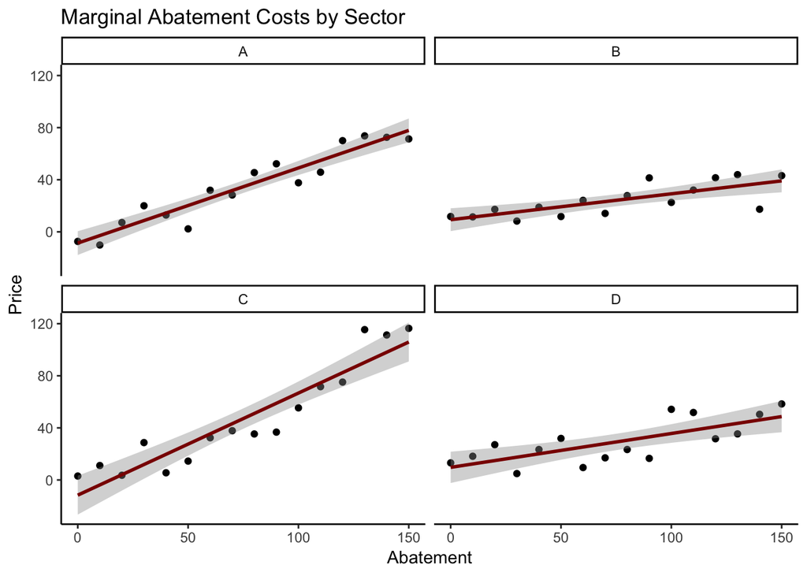

### Demand of Emissions

At any quanity, x, the marginal cost of abatement can be obtained using the above functions and substracting “x” from the current emissions scenario. The demand curves for each sector were determined through sequential marginal willingness to pay estimations.

## Cutting Carbon Emissions in Half: Analyzing 3 Policies for Country X

#### Policy Option 1: A Cap on Carbon

Marginal cost of abatement curves for each sector are used to calculate the total cost of abating by 100 tons. The area underneath the marginal cost of abatement curve from 0 to 100 gives the total cost of abatement for that sector. The total cost of carbon cap is the sum of the costs of three sectors.

1. Total Cost of Carbon Cap

The total cost of the carbon cap is $6698.88

2. The Total Cost of a Carbon Cap for Each Sector

The total cost for Sector A is $2019.76

The total cost for Sector B is $1925.49

The total cost for Sector C is $2753.63

3. The Tax Revenue Generated from a Carbon Cap

There is no tax revenue generated with a carbon cap

#### Policy Option 2: A Tax on Carbon

1. The Total Cost of a Carbon Tax

The optimal tax is $39.43

This tax is equal to the marginal cost of abatement for the 300th ton of carbon for Country “X” when the desired abatement (300 tons) is substituted into the aggregate demand function for all sectors.

The total cost of a carbon tax is $17707.79

2. The Total Cost of a Carbon Tax for Each Sector

The cost to Sector A is $5095.16

The cost to Sector B is $5604.46

The cost to Sector C is $7008.16

3. The Tax Revenue Generated from a Carbon Tax

The total tax revenue is $11827.97

#### Policy Option 3: A Cap and Trade Program

1. The Total Cost of a Carbon Cap and Trade Program

The total cost of a carbon cap and trade program is $5997.74

2. The Total Cost of a Carbon Cap and Trade Program for Each Sector

The cost to Sector A is $1939.66

The cost to Sector B is $1779.91

The cost to Sector C is $2278.18

3. The Tax Revenue Generated from a Carbon Tax

There is no tax revenue generated with cap and trade program

## Country “Y”" Joining the Carbon Market of Country “X”"

1. The Total Cost of a Carbon Cap and Trade Program with Both Countries

The total cost of a carbon cap and trade program is $4729.11

2. The Total Cost of a Carbon Cap and Trade Program for Each Sector

The cost to Sector A is $1698.99

The cost to Sector B is $1924.55

The cost to Sector C is $1883.88

The benefit to Sector D is $778.32

3. The Tax Revenue Generated from a Carbon Tax

There is no tax revenue generated with cap and trade program.

Country “Y” is incentivised to join the market with Country “X” because it will have a benefit of $778.32 if it sells all of its carbon credits to the other three sectors. While the sectors in Country “X” still have to purchase under the cap and trade program, the addition of Country “Y” lowers the marginal cost of abatement for each ton of carbon. Without the addition of Sector D, the marginal cost of abatement for Country “X” is 39.43 dollars, whereas with Country “Y” it is only 29.80 dollars for 300 tons. Thus Country “X” is incentivised to welcome Sector D into its market.

## Air Pollution

1. In a market of just Country “X” the local air pollution would be 300 tons. (300 tons carbon emissions*1 ton local air pollution). If Country “Y” is not limited by cap and trade it will emits current scenario of 300 tons of carbon, also generating 300 tons of local pollutants.
2. If Country “Y” joins the Cap and Trade Program, Country “X” will be emitting more carbon. Thus its local pollution will rise from 300 tons to 377.39 tons after purchasing the 77.39 abatement tons from Country “Y”. Since Country “Y” sells some of its carbon emissions, it will have less local pollution. Its local air pollution will be reduced from 300 tons to 222.61 tons.